# Untitled

Brooks Coetzee III

2022-09-21

```r
### Packages

library(httr) # httr is organised around the six most common http verbs: GET(), PATCH(), POST(), HEAD(), PUT(), and DELETE().
library(rvest) # Easily Harvest (Scrape) Web Pages
library(tidyverse)
library(jsonlite)  ## These functions are used to convert between JSON data and R objects.
library(lubridate)  ## Lubridate provides tools that make it easier to parse and manipulate dates.
```

```r
library(readxl)
library(ggplot2)
library(xgboost)
library(randomForest)
```

Definition of variables *FPTS: Total Fantansy for that season* FPPG: Fantasy Points per game *GP: Games Played* TPA: Total Plate Appearances *AB: At bats* R: Runs *H: Hits* 1B,2B,3B: Singles, Doubles, Triples *HR: Homeruns* RBI: Runs Batted In *AVG: Batting Average* OBP: On Base Percentage *SLG: Slugging* OPS: One base plus slugging *BB: Walks* SO: Strike Outs *TB: Total Bases* SB: Stolen Bases *CS: Caught Stealing* HBP: Hit By Pitch *SH: Sac Hit* SF: Sac Fly *E: Error* A: Assists *GDP: Grounded into Double Play

2021 Season Stats

```r
baseball_2021 <- read_excel('Baseball_Data_2021.xlsx')
summary(baseball_2021)
```

```
##     PLAYER               FPTS            FPPG            GP
##  Length:100         Min.   :362.5   Min.   :2.30   Min.   :110.0
##  Class :character   1st Qu.:394.4   1st Qu.:2.70   1st Qu.:141.0
##  Mode  :character   Median :428.2   Median :3.00   Median :148.0
##                     Mean   :446.9   Mean   :3.05   Mean   :146.8
##                     3rd Qu.:490.4   3rd Qu.:3.30   3rd Qu.:156.0
##                     Max.   :641.0   Max.   :4.00   Max.   :162.0
##       TPA              AB              R                H
##  Min.   :471.0   Min.   :399.0   Min.   : 64.00   Min.   : 99.0
##  1st Qu.:575.5   1st Qu.:505.0   1st Qu.: 77.00   1st Qu.:132.0
##  Median :615.5   Median :534.5   Median : 86.00   Median :146.5
##  Mean   :612.5   Mean   :540.2   Mean   : 87.08   Mean   :145.7
##  3rd Qu.:653.0   3rd Qu.:572.5   3rd Qu.: 94.00   3rd Qu.:160.8
##  Max.   :724.0   Max.   :664.0   Max.   :123.00   Max.   :195.0
##        1B               2B             3B                  HR
##  Min.   : 47.00   Min.   :13.00   Length:100         Min.   : 2.00
##  1st Qu.: 74.00   1st Qu.:24.75   Class :character   1st Qu.:20.75
##  Median : 86.00   Median :30.00   Mode  :character   Median :27.00
##  Mean   : 88.08   Mean   :29.20                      Mean   :26.34
##  3rd Qu.:102.00   3rd Qu.:34.00                      3rd Qu.:33.00
##  Max.   :136.00   Max.   :42.00                      Max.   :48.00
##       RBI              AVG              OBP              SLG
##  Min.   : 43.00   Min.   :0.1990   Min.   :0.2810   Min.   :0.3420
##  1st Qu.: 70.75   1st Qu.:0.2550   1st Qu.:0.3307   1st Qu.:0.4422
##  Median : 83.50   Median :0.2670   Median :0.3490   Median :0.4825
##  Mean   : 82.79   Mean   :0.2695   Mean   :0.3480   Mean   :0.4792
##  3rd Qu.: 98.00   3rd Qu.:0.2863   3rd Qu.:0.3653   3rd Qu.:0.5220
##  Max.   :121.00   Max.   :0.3280   Max.   :0.4650   Max.   :0.6150
##       OPS               BB               SO              TB
##  Min.   :0.6600   Min.   : 22.00   Min.   : 68.0   Min.   :188.0
##  1st Qu.:0.7790   1st Qu.: 48.00   1st Qu.:104.5   1st Qu.:230.2
##  Median :0.8215   Median : 59.00   Median :127.0   Median :252.0
##  Mean   :0.8272   Mean   : 59.59   Mean   :127.6   Mean   :258.1
##  3rd Qu.:0.8740   3rd Qu.: 67.00   3rd Qu.:148.5   3rd Qu.:288.8
##  Max.   :1.0440   Max.   :145.00   Max.   :213.0   Max.   :363.0
##       SB                 CS                HBP                 SH
##  Length:100         Length:100         Length:100         Length:100
##  Class :character   Class :character   Class :character   Class :character
##  Mode  :character   Mode  :character   Mode  :character   Mode  :character
##
##
##
##       SF                 E                  A                  GDP
##  Length:100         Length:100         Length:100         Min.   : 2.00
##  Class :character   Class :character   Class :character   1st Qu.: 7.00
##  Mode  :character   Mode  :character   Mode  :character   Median :10.50
##                                                           Mean   :10.95
##                                                           3rd Qu.:14.00
##                                                           Max.   :28.00
```

```r
head(baseball_2021)
```

```
## # A tibble: 6 x 28
##   PLAYER  FPTS  FPPG    GP   TPA    AB     R     H  `1B`  `2B` `3B`     HR   RBI
##   <chr>  <dbl> <dbl> <dbl> <dbl> <dbl> <dbl> <dbl> <dbl> <dbl> <chr> <dbl> <dbl>
## 1 Vladi~  641    4     161   698   604   123   188   110    29 1.0      48   111
## 2 Jose ~  596.   3.9   152   636   552   111   147    74    32 5.0      36   103
## 3 Marcu~  593    3.7   162   724   652   115   173    87    39 2.0      45   102
## 4 Juan ~  586.   3.9   151   654   502   111   157   106    20 2.0      29    95
## 5 Shohe~  568.   3.6   158   639   537   103   138    58    26 8.0      46   100
## 6 Matt ~  564.   3.6   156   673   565   101   153    79    35 —        39   111
## # ... with 15 more variables: AVG <dbl>, OBP <dbl>, SLG <dbl>, OPS <dbl>,
## #   BB <dbl>, SO <dbl>, TB <dbl>, SB <chr>, CS <chr>, HBP <chr>, SH <chr>,
## #   SF <chr>, E <chr>, A <chr>, GDP <dbl>
```

```r
tail(baseball_2021)
```

```
## # A tibble: 6 x 28
##   PLAYER  FPTS  FPPG    GP   TPA    AB     R     H  `1B`  `2B` `3B`     HR   RBI
##   <chr>  <dbl> <dbl> <dbl> <dbl> <dbl> <dbl> <dbl> <dbl> <dbl> <chr> <dbl> <dbl>
## 1 Jorge~  369    2.5   149   602   516    74   115    61    27 —        27    70
## 2 Yoan ~  368.   2.6   144   616   520    74   137    89    33 1.0      14    61
## 3 Nicky~  368    2.4   151   565   497    78   149   120    21 6.0       2    43
## 4 Cesar~  364.   2.4   149   637   570    84   132    88    21 2.0      21    62
## 5 J.T. ~  364.   2.7   134   537   476    64   125    79    25 4.0      17    73
## 6 Mike ~  362.   2.6   139   532   468    75   105    49    28 3.0      25    71
## # ... with 15 more variables: AVG <dbl>, OBP <dbl>, SLG <dbl>, OPS <dbl>,
## #   BB <dbl>, SO <dbl>, TB <dbl>, SB <chr>, CS <chr>, HBP <chr>, SH <chr>,
## #   SF <chr>, E <chr>, A <chr>, GDP <dbl>
```

```r
sum(is.na(baseball_2021))
```

```
## [1] 0
```

```r
#0 NA values
```

Density Plots:

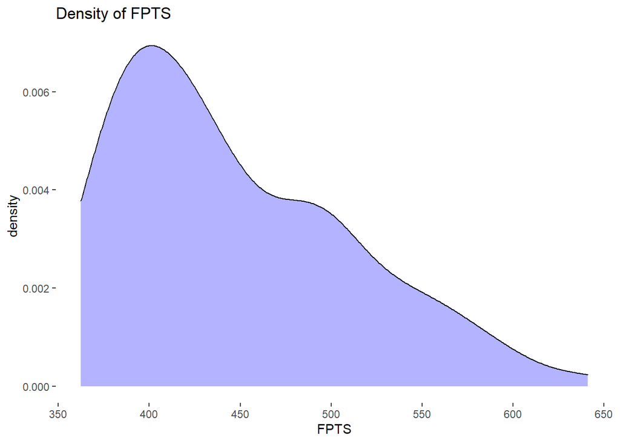

```r
# Create plot
g_1 <- ggplot(baseball_2021, aes(x = FPTS)) + # Set X-axis as insurance charges
  geom_density(fill = "blue", alpha = 0.3) + # Use geom_density to get density plot
  theme_bw() + # Set theme for plot
  theme(panel.grid.major = element_blank(), # Turn of the background grid
        panel.grid.minor = element_blank(),
        panel.border = element_blank(),
        panel.background = element_blank()) +
  labs(x = "FPTS", # Set plot labels
       title = "Density of FPTS")

g_1 # Generate plot
```

```r
#Great density in the 400 for PTS on the year
```

relation between FPPG and AVG

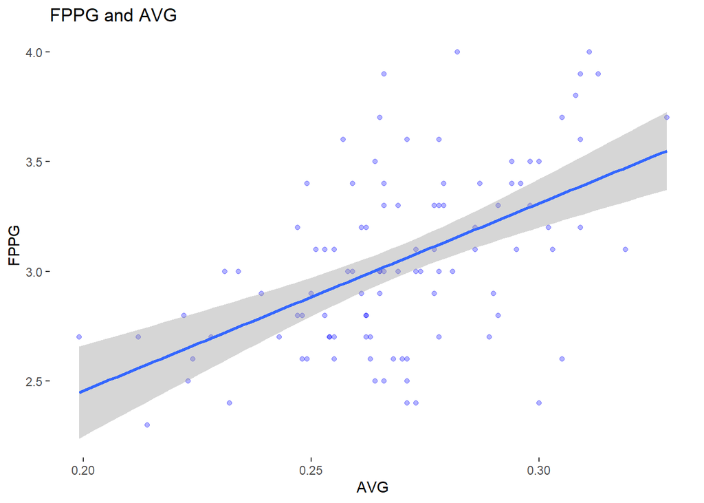

```r
g_3 <- ggplot(baseball_2021, # Set dataset
              aes(y = FPPG, # Set y-axis as insurance charges
                  x = AVG)) + # Set x-axis as age.
  geom_point(color = "blue", alpha = 0.3) + # Use geom_point to get scatter plot
  geom_smooth(method = "lm") + # Add smoothing line
  theme_bw() + # Set theme for plot
  theme(panel.grid.major = element_blank(), # Turn of the background grid
        panel.grid.minor = element_blank(),
        panel.border = element_blank(),
        panel.background = element_blank()) +
  labs(y = "FPPG", # Set plot labels
       x = "AVG",
       title = "FPPG and AVG")

g_3
```

```r
#There is a positive correlation with a wide standard error. this shows that there is a correlation between AVG and fantasy points per game.
```

2022 Season

```r
#as of September 20, 2022
baseball_2022 <- read_excel('Baseball_Data_2022_Updated.xlsx')
summary(baseball_2022)
```

```
##     PLAYER               FPTS            FPPG             GP
##  Length:100         Min.   :333.5   Min.   :2.300   Min.   : 98.0
##  Class :character   1st Qu.:359.4   1st Qu.:2.600   1st Qu.:136.0
##  Mode  :character   Median :411.0   Median :2.800   Median :147.0
##                     Mean   :418.6   Mean   :2.914   Mean   :143.6
##                     3rd Qu.:459.9   3rd Qu.:3.200   3rd Qu.:152.2
##                     Max.   :706.0   Max.   :4.600   Max.   :160.0
##       TPA              AB              R                H
##  Min.   :422.0   Min.   :366.0   Min.   : 46.00   Min.   : 91.0
##  1st Qu.:557.5   1st Qu.:500.8   1st Qu.: 69.75   1st Qu.:129.8
##  Median :605.0   Median :537.0   Median : 76.50   Median :140.0
##  Mean   :602.9   Mean   :536.2   Mean   : 79.03   Mean   :143.2
##  3rd Qu.:648.2   3rd Qu.:575.2   3rd Qu.: 89.00   3rd Qu.:157.5
##  Max.   :711.0   Max.   :650.0   Max.   :131.00   Max.   :196.0
##        1B               2B             3B                  HR
##  Min.   : 47.00   Min.   :18.00   Length:100         Min.   : 6.00
##  1st Qu.: 78.25   1st Qu.:24.00   Class :character   1st Qu.:15.00
##  Median : 88.00   Median :28.00   Mode  :character   Median :20.50
##  Mean   : 89.09   Mean   :29.62                      Mean   :22.34
##  3rd Qu.: 99.00   3rd Qu.:35.00                      3rd Qu.:28.25
##  Max.   :132.00   Max.   :46.00                      Max.   :61.00
##       RBI              AVG              OBP              SLG
##  Min.   : 46.00   Min.   :0.1980   Min.   :0.2950   Min.   :0.3760
##  1st Qu.: 63.00   1st Qu.:0.2490   1st Qu.:0.3207   1st Qu.:0.4155
##  Median : 75.50   Median :0.2650   Median :0.3360   Median :0.4495
##  Mean   : 76.97   Mean   :0.2670   Mean   :0.3403   Mean   :0.4553
##  3rd Qu.: 88.25   3rd Qu.:0.2843   3rd Qu.:0.3580   3rd Qu.:0.4783
##  Max.   :131.00   Max.   :0.3260   Max.   :0.4260   Max.   :0.6860
##       OPS               BB               SO               TB
##  Min.   :0.6780   Min.   : 20.00   Min.   : 43.00   Min.   :174.0
##  1st Qu.:0.7428   1st Qu.: 41.00   1st Qu.: 95.75   1st Qu.:219.0
##  Median :0.7870   Median : 53.50   Median :116.50   Median :237.5
##  Mean   :0.7956   Mean   : 54.49   Mean   :118.06   Mean   :244.1
##  3rd Qu.:0.8265   3rd Qu.: 63.00   3rd Qu.:141.50   3rd Qu.:269.0
##  Max.   :1.1120   Max.   :135.00   Max.   :199.00   Max.   :386.0
##       SB                 CS                HBP                 SH
##  Length:100         Length:100         Length:100         Length:100
##  Class :character   Class :character   Class :character   Class :character
##  Mode  :character   Mode  :character   Mode  :character   Mode  :character
##
##
##
##       SF                 E                  A                  GDP
##  Length:100         Length:100         Length:100         Min.   : 2.00
##  Class :character   Class :character   Class :character   1st Qu.: 8.00
##  Mode  :character   Mode  :character   Mode  :character   Median :11.00
##                                                           Mean   :11.69
##                                                           3rd Qu.:14.00
##                                                           Max.   :26.00
```

```r
head(baseball_2022)
```

```
## # A tibble: 6 x 28
##   PLAYER  FPTS  FPPG    GP   TPA    AB     R     H  `1B`  `2B` `3B`     HR   RBI
##   <chr>  <dbl> <dbl> <dbl> <dbl> <dbl> <dbl> <dbl> <dbl> <dbl> <chr> <dbl> <dbl>
## 1 Aaron~  706    4.6   155   689   563   131   175    86    28 —        61   130
## 2 Fredd~  581    3.7   157   700   604   116   196   128    46 2        20    98
## 3 Jose ~  580.   3.7   155   676   592    88   163    87    42 5        29   122
## 4 Paul ~  572    3.8   150   648   558   106   178   102    41 —        35   114
## 5 Pete ~  553    3.5   158   678   592    94   159    92    27 —        40   131
## 6 Mooki~  536.   3.8   140   634   568   116   154    76    40 3        35    82
## # ... with 15 more variables: AVG <dbl>, OBP <dbl>, SLG <dbl>, OPS <dbl>,
## #   BB <dbl>, SO <dbl>, TB <dbl>, SB <chr>, CS <chr>, HBP <chr>, SH <chr>,
## #   SF <chr>, E <chr>, A <chr>, GDP <dbl>
```